# Differential expression and pathway analysis in prostate cancer

TCGA-PRAD tumor vs matched normal, with independent validation and an exploratory ancestry analysis

Author

Kipchumba

Published

November 3, 2026

# Summary

# 1 Data and design

|  | Discovery | Validation |
| --- | --- | --- |
| Cohort | TCGA-PRAD (GDC) | GEO GSE104131 |
| Samples | 52 tumor / matched normal pairs | 13 pairs (7 African-American, 6 European-American) |
| Tumors | All Gleason grades | High grade (Gleason ≥ 4+3) |
| Counts | GDC STAR counts (GENCODE v36), unstranded | NCBI-generated raw counts (GRCh38.p13) |
| Model | DESeq2, `~ patient + condition` | DESeq2, `~ pair + condition` |

All steps run as a Snakemake pipeline. Pairing keeps one aliquot per patient and sample type. Thresholds throughout: FDR < 0.05; DEG lists additionally require |log<sub>2</sub>FC| ≥ 1 on apeglm-shrunken estimates.

# 2 Quality control

Genes were kept if they had ≥ 10 reads in at least 52 samples (the size of each group), leaving 20,303 genes. After variance-stabilising transformation, the first two principal components separate tumor from normal. Neither tissue source site nor sequencing plate is associated with them, so no batch correction was applied.

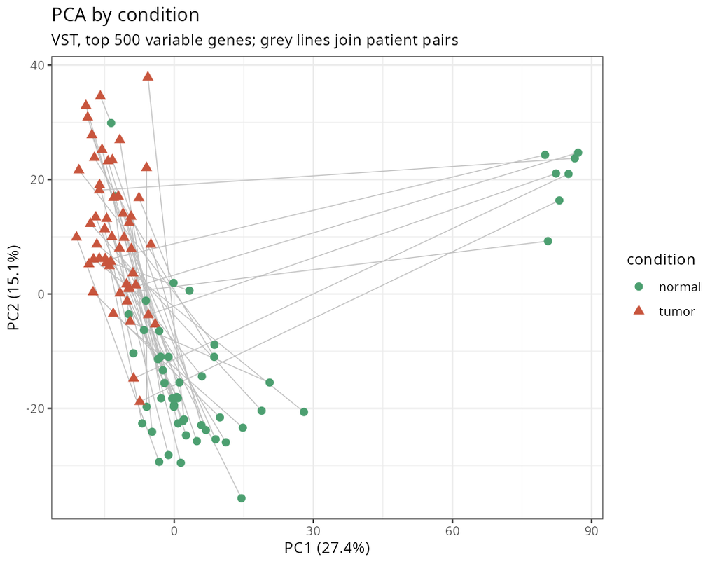

Figure 1: PCA of the 500 most variable genes. Grey lines join each patient’s tumor and normal sample.

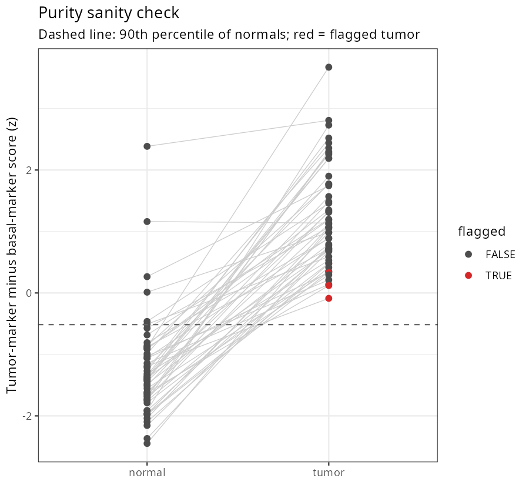

Figure 2: Marker-based purity check. Lines join pairs; dashed line is the 90th percentile of normals.

# 3 Differential expression

12,752 genes differ at FDR < 0.05 (63% of those tested), which is expected with 52 well-matched pairs. Requiring a 2-fold change gives 2,233 DEGs. More genes fall than rise in tumors. That fits tumors replacing normal fibromuscular stroma and basal cells.

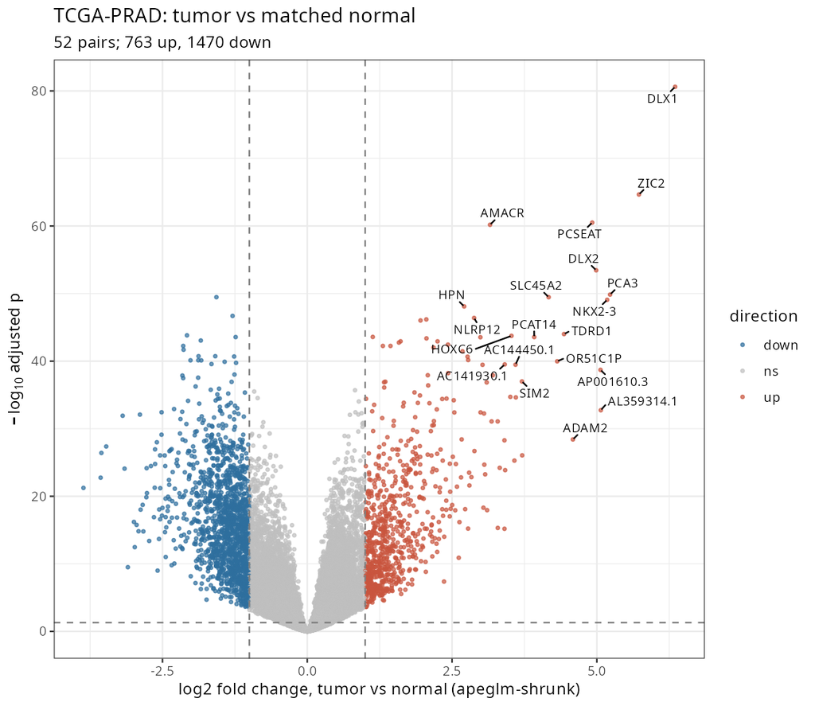

Figure 3: Volcano plot. Fold changes are apeglm-shrunken.

Top 15 DEGs by adjusted p-value

| Gene | Type | log2FC (shrunk) | Adjusted p |
| --- | --- | --- | --- |
| DLX1 | protein_coding | 6.35 | 0 |
| ZIC2 | protein_coding | 5.73 | 0 |
| PCSEAT | lncRNA | 4.92 | 0 |
| AMACR | protein_coding | 3.16 | 0 |
| DLX2 | protein_coding | 4.99 | 0 |
| PCA3 | lncRNA | 5.23 | 0 |
| SLC45A2 | protein_coding | 4.17 | 0 |
| TMLHE | protein_coding | -1.57 | 0 |
| NKX2-3 | protein_coding | 5.18 | 0 |
| HPN | protein_coding | 2.71 | 0 |
| TRIP6 | protein_coding | -1.29 | 0 |
| NLRP12 | protein_coding | 2.88 | 0 |
| FOXP4-AS1 | lncRNA | 2.06 | 0 |
| H2AW | protein_coding | 1.96 | 0 |
| TDRD1 | protein_coding | 4.43 | 0 |

The leading genes are among the best-validated prostate cancer markers: AMACR, PCA3, HPN, DLX1 and TDRD1, as well as the prostate-cancer-associated lncRNA PCSEAT. Five of these were also in the QC marker score. That is not circular, because the score was used only to flag samples, never to select them.

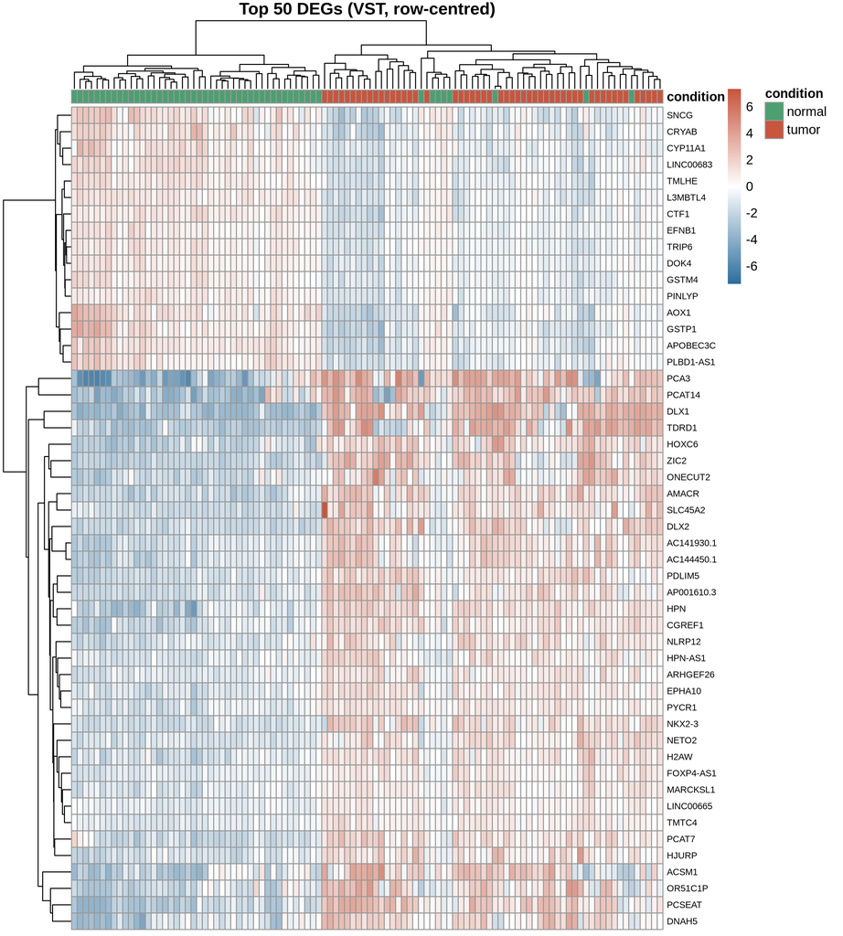

Figure 4: Top 50 DEGs (VST, row-centred).

## 3.1 Sensitivity to borderline-purity tumors

Refitting without the 4 flagged pairs (48 pairs) gives 2,533 DEGs versus 2,480 on matching thresholds. The two lists overlap with Jaccard = 0.871, all overlapping genes change in the same direction, and fold changes correlate at ρ = 0.993.

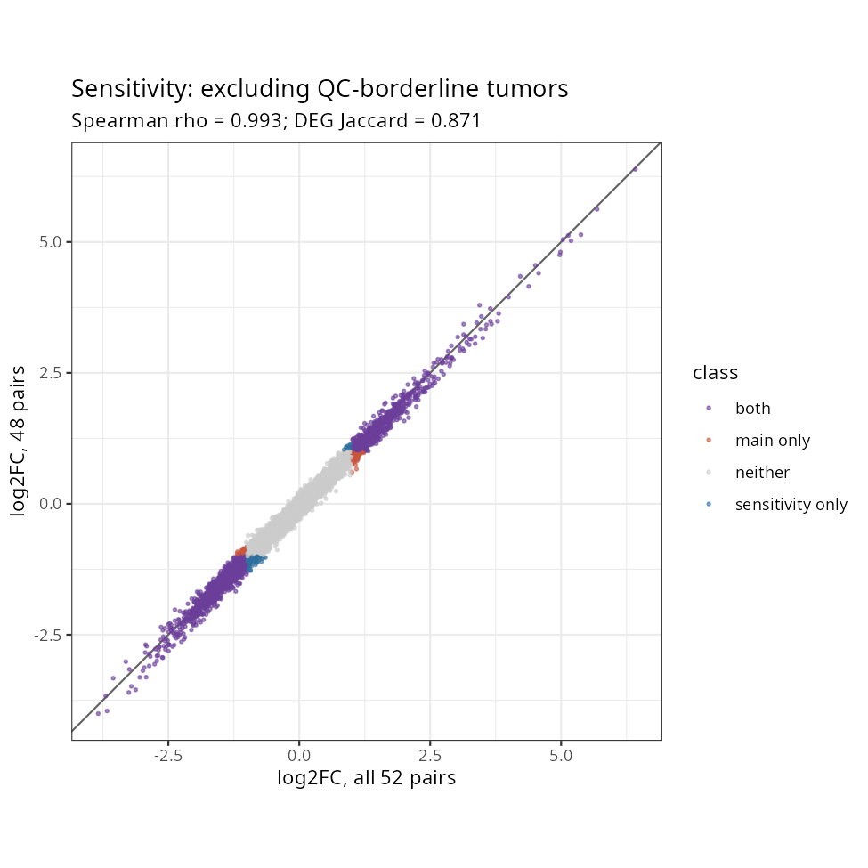

Figure 5: Fold changes with and without the flagged pairs.

# 4 Pathway analysis

Genes were ranked by the DESeq2 Wald statistic, keeping one Ensembl ID per symbol. fgsea then ran on MSigDB Hallmark and Reactome sets of 15–500 genes. Redundant Reactome pathways were collapsed with `collapsePathways`.

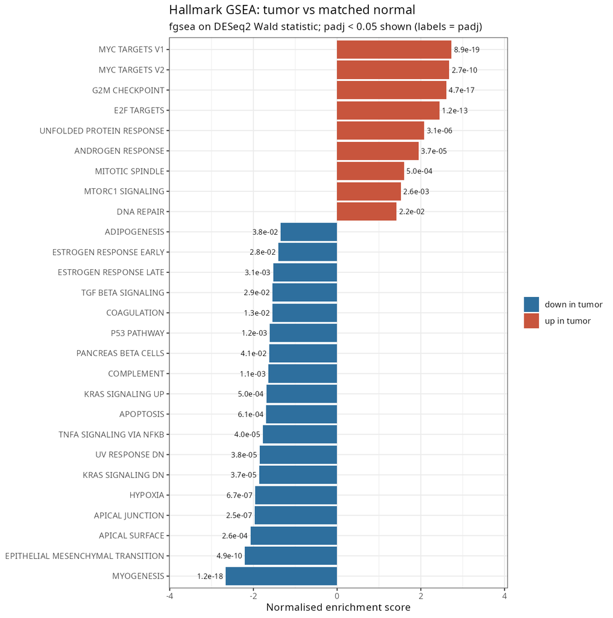

Figure 6: Significant Hallmark sets (labels show adjusted p).

**Up in tumor:** MYC TARGETS V1, MYC TARGETS V2, G2M CHECKPOINT, E2F TARGETS, UNFOLDED PROTEIN RESPONSE, ANDROGEN RESPONSE, MITOTIC SPINDLE, MTORC1 SIGNALING, DNA REPAIR. MYC activation and androgen-receptor signalling are hallmark features of prostate adenocarcinoma, and the proliferation sets reflect a higher mitotic index.

**Down in tumor:** MYOGENESIS, EPITHELIAL MESENCHYMAL TRANSITION, APICAL SURFACE, APICAL JUNCTION, HYPOXIA, KRAS SIGNALING DN, UV RESPONSE DN, TNFA SIGNALING VIA NFKB, APOPTOSIS, KRAS SIGNALING UP, COMPLEMENT, PANCREAS BETA CELLS, P53 PATHWAY, COAGULATION, TGF BETA SIGNALING, ESTROGEN RESPONSE LATE, ESTROGEN RESPONSE EARLY, ADIPOGENESIS. Most of these sets are dominated by smooth-muscle, fibroblast and immune genes. In bulk RNA-seq they largely reflect **tissue composition**: tumors contain less fibromuscular stroma than normal prostate. They are not evidence that tumor cells switch these programmes off. The Hallmark “EMT” set falls for the same reason, because it is mostly stromal genes such as collagens.

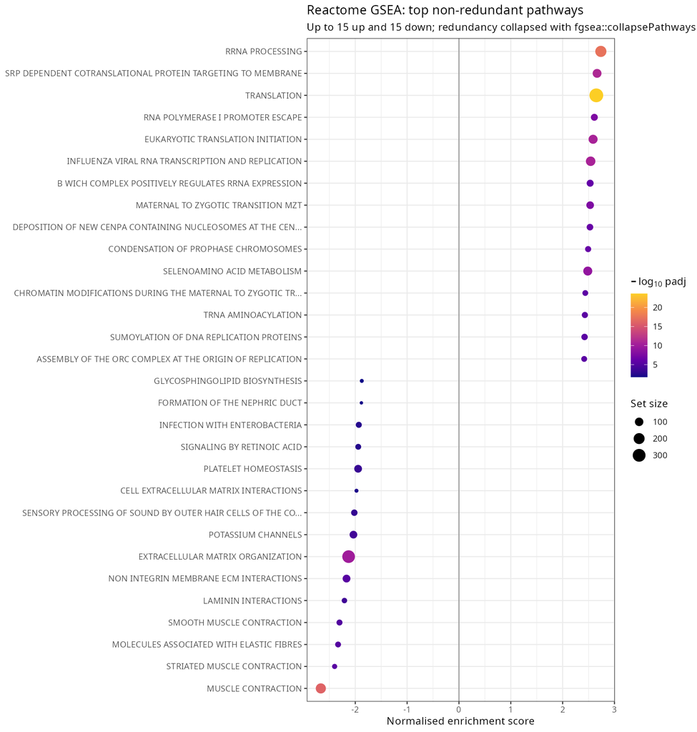

Figure 7: Top non-redundant Reactome pathways.

Of the 27 significant Hallmark sets, 10 were also significant by over-representation analysis of the DEG lists. ORA only sees genes past the 2-fold cutoff. Proliferation genes typically move less than 2-fold but move together, so GSEA detects them and ORA misses them.

# 5 Independent validation (GSE104131)

GSE104131 contains 16 high-grade tumor / adjacent-normal pairs (8 African-American, 8 European-American). Four libraries are absent from the NCBI count matrix, leaving 13 complete pairs.

Replication of TCGA findings in GSE104131

| Check | Result |
| --- | --- |
| TCGA DEGs measured in GEO | 1,863 |
| Same direction in GEO | 92% |
| Also FDR < 0.05 in GEO | 709 |
| Fold-change correlation, all shared genes | ρ = 0.684 |
| TCGA signature AUC (tumor vs normal) | 0.982 |
| Pairs where tumor scores higher | 12 / 13 |
| Hallmark NES correlation | r = 0.726 |
| Hallmark sets replicated | 20 / 27 |

Direction agreement is far beyond chance (binomial p < 10<sup>-16</sup>). Many TCGA DEGs do not reach significance in GEO because 13 pairs give much less power, but they point the same way. The cohort is restricted to high-grade tumors, which makes this a stricter test than a grade-matched replication.

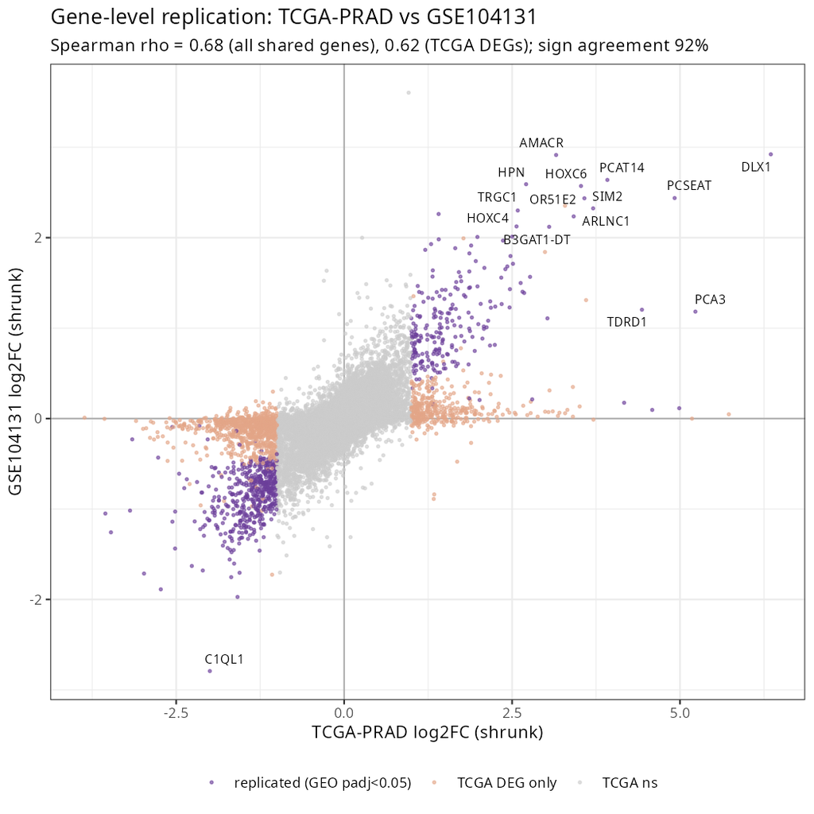

Figure 8: Left: gene-level fold changes. Right: TCGA signature score in GEO samples.

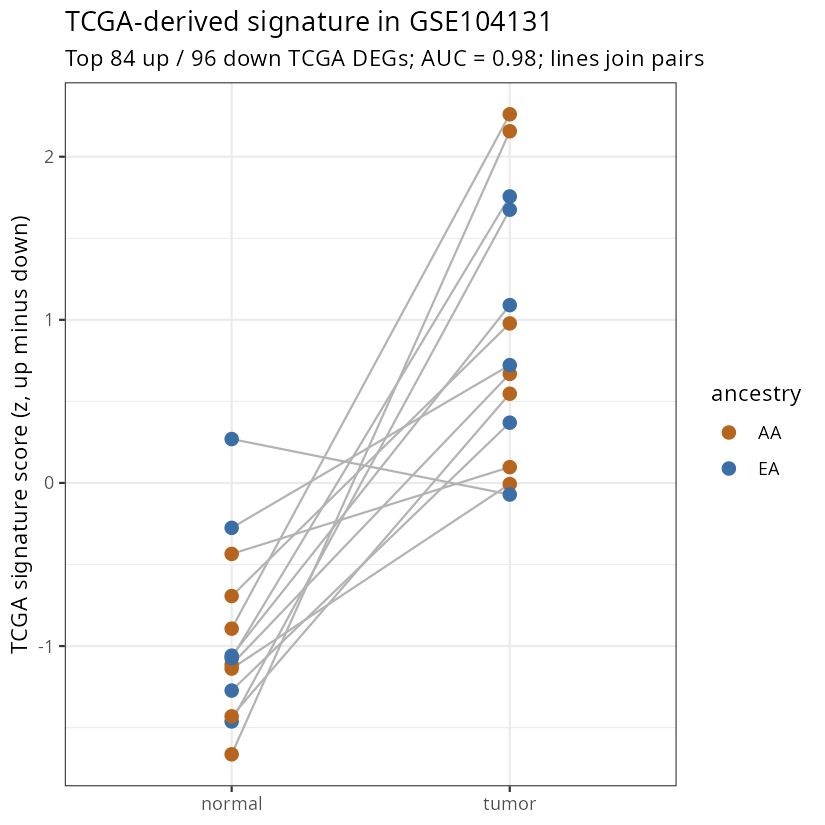

Figure 9: Left: gene-level fold changes. Right: TCGA signature score in GEO samples.

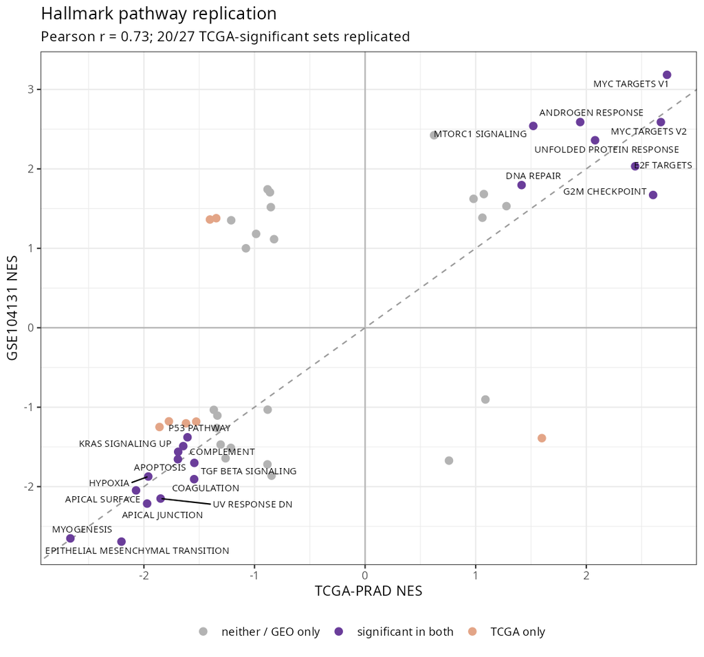

Figure 10: Hallmark NES in TCGA vs GSE104131.

# 6 Exploratory ancestry analysis

TCGA-PRAD has few patients of African ancestry. Only 7 of the 52 paired patients self-report as Black or African American, which is too few for a paired subgroup analysis. Two complementary analyses were therefore run. Both rely on **self-reported race or ethnicity, which is not genetic ancestry**.

## 6.1 Does the tumor effect differ by ancestry? (GSE104131)

Pairs were nested within ancestry (7 AA, 6 EA). At gene level, 2 genes had an ancestry-specific tumor effect. At pathway level, each patient was treated as one observation. For each pair and Hallmark set, the score is the mean tumor-minus-normal change of the set’s genes, compared between AA and EA with an exact Wilcoxon test. **No set differed** (smallest raw p = 0.14).

An earlier version ranked genes by the interaction statistic and ran pre-ranked GSEA. That flagged 41 of 50 sets, with p-values below 10<sup>-20</sup>. Pre-ranked GSEA treats genes as independent. With 13 patients, a few atypical pairs shift thousands of correlated genes together, so those p-values were far too small. The patient-level test replaces it. This cohort does not support or rule out ancestry-specific tumor biology. It is simply underpowered.

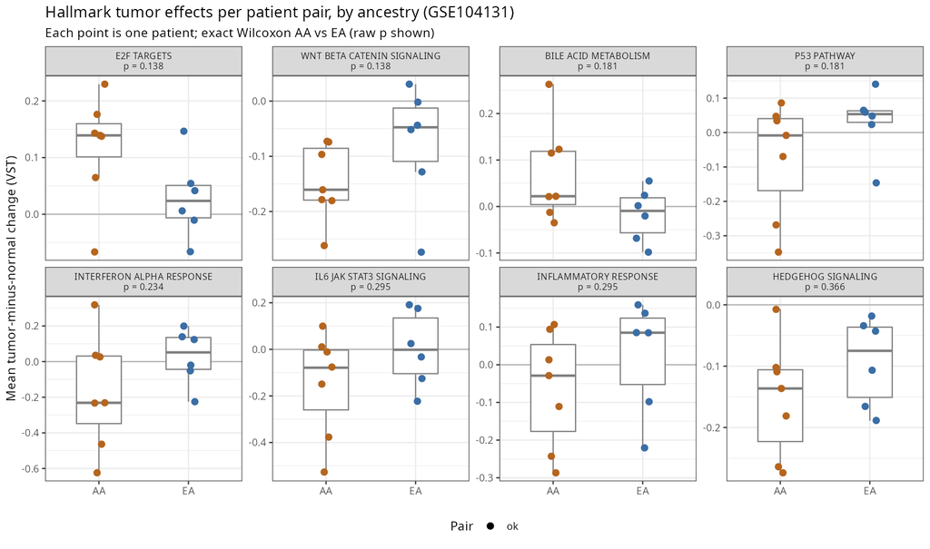

Figure 11: Per-pair Hallmark tumor effects for the eight lowest-p sets.

## 6.2 Tumors from Black vs White patients (TCGA)

57 tumors from Black and 384 from White patients were compared, adjusting for Gleason group and age. Grade differs markedly between the groups: 14% vs 44% Gleason 8–10.

**A mapping artifact.** Before filtering, the strongest “race” genes were mitochondrial pseudogenes (15 significant, 14 higher in Black patients). The likely cause is that African mitochondrial haplogroups differ from the European reference mitochondrial genome. Some mitochondrial reads then align to nuclear copies of mitochondrial DNA instead. These were removed, and DEG reporting was restricted to protein-coding and lncRNA genes.

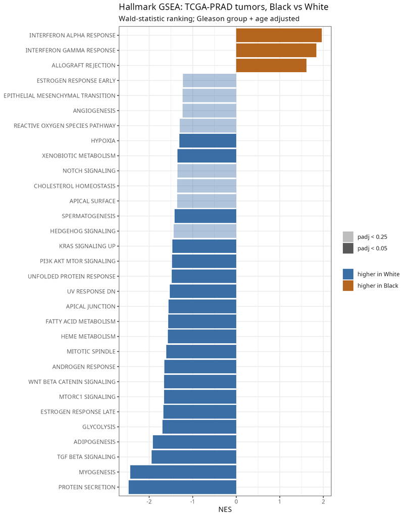

Figure 12: Hallmark GSEA, Black vs White tumors.

Immune and interferon sets, main model vs site-matched model

| Pathway | NES (all sites) | padj | NES (site-matched) | padj |
| --- | --- | --- | --- | --- |
| INTERFERON GAMMA RESPONSE | 1.84 | 2.2e-05 | 2.01 | 8.0e-07 |
| INTERFERON ALPHA RESPONSE | 1.96 | 1.3e-04 | 1.82 | 1.0e-03 |
| TNFA SIGNALING VIA NFKB | 0.75 | 1.0e+00 | 1.66 | 1.0e-03 |
| ALLOGRAFT REJECTION | 1.61 | 1.7e-03 | 1.63 | 1.9e-03 |
| INFLAMMATORY RESPONSE | 1.04 | 4.6e-01 | 1.39 | 3.7e-02 |

Interferon-α, interferon-γ and allograft-rejection sets are higher in tumors from Black patients. This agrees with earlier reports of an interferon and immune-inflammation signature in African-American prostate tumors (Wallace et al. 2008; Awasthi et al. 2021). Because Black patients come mostly from a few tissue source sites, race and site are confounded. Restricting to sites with ≥ 3 Black and ≥ 3 White patients (47 vs 217) and adding site to the model leaves the interferon result intact. TNFα/NF-κB and inflammatory-response sets also become significant. The stromal and metabolic sets lower in Black patients are less stable: overall NES correlation between the two models is r = 0.595.

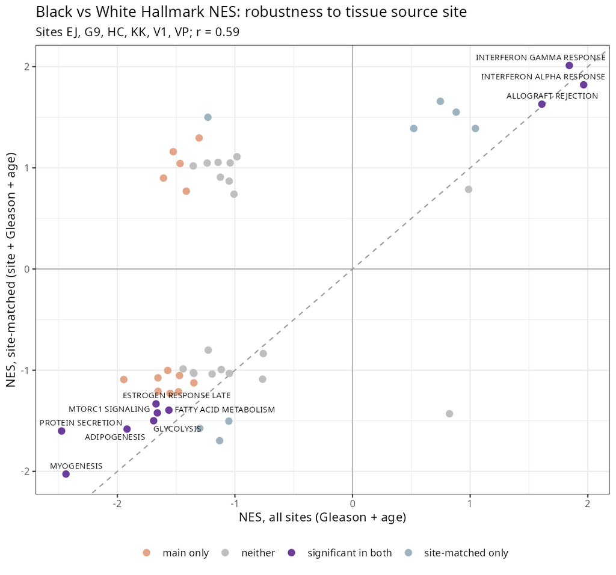

Figure 13: Robustness of race-associated Hallmark NES to tissue source site.

Several top individual genes (e.g. TDO2, RBM44, MAEL, TRIM31) show large, consistent shifts. Large single-gene differences between population groups can come from inherited variants rather than tumor biology; this is tested with genetic ancestry in the next section.

# 7 Genetic ancestry

Self-reported race is a social category, not a measure of genetic ancestry. Per-patient ancestry proportions estimated from germline genotypes by the TCGA Ancestry & Molecular Correlates group (Carrot-Zhang et al. 2020; source file: Admixture_by_sample.txt) were used instead. **AFR** below is the fraction of a patient’s genome estimated to be of African ancestry (0–1).

Genetic African-ancestry fraction by self-reported race (TCGA-PRAD primary tumors)

| Self-reported race | n | Median AFR | Range | AFR ≥ 0.5 |
| --- | --- | --- | --- | --- |
| White | 394 | 0.00 | 0.00–0.89 | 2 |
| Other/unknown | 24 | 0.01 | 0.00–0.47 | 0 |
| Black | 53 | 0.80 | 0.00–1.00 | 51 |

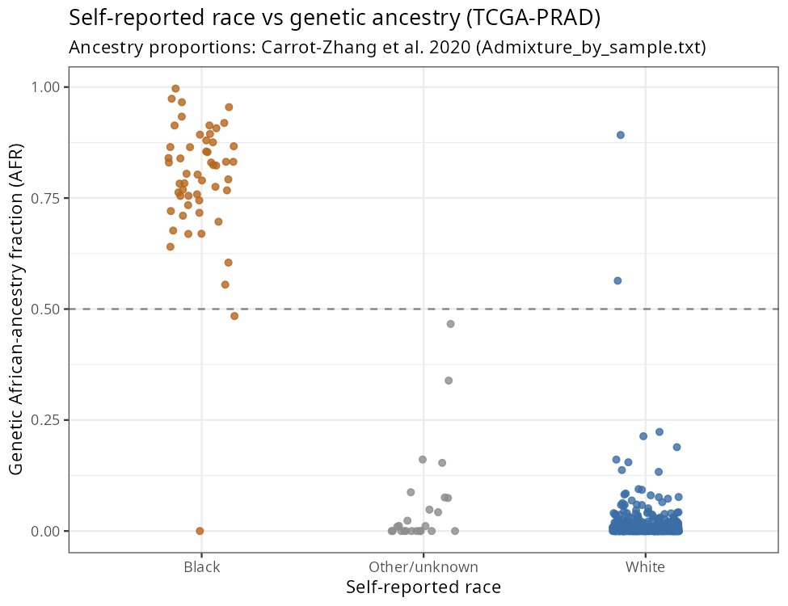

Figure 14: Self-reported race vs genetic African-ancestry fraction.

Self-identified Black patients have a median AFR of 0.805 (minimum 0), the admixed range typical of African Americans. The highest AFR among self-identified White patients is 0.892.

## 7.1 Expression and African-ancestry fraction

Tumors from patients of two-way African/European ancestry (416 tumors, 53 with AFR ≥ 0.5) were modelled as `~ Gleason group + age + AFR`. Treating ancestry as a continuous dose uses the variation within admixed patients, rather than a two-group label. 2857 protein-coding or lncRNA genes are associated with AFR at FDR < 0.05, and 22 Hallmark sets are enriched.

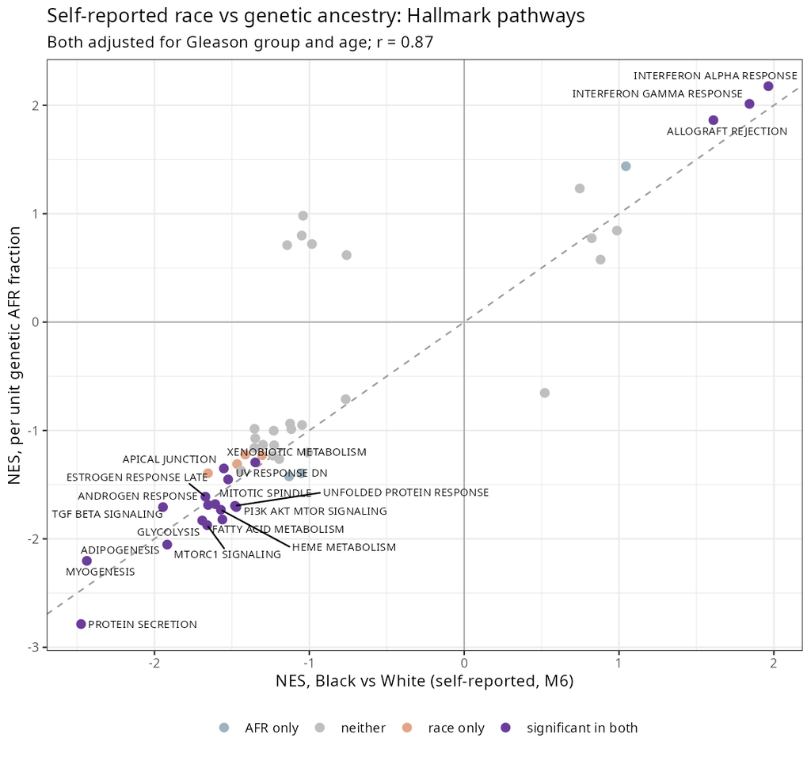

Figure 15: Hallmark NES by self-reported race (M6) vs by genetic AFR fraction.

Gene-set tests rank genes and treat them as independent, so co-regulated genes such as an interferon programme can make the p-value look more certain than the data allow. The patient-level test below scores each tumor once and regresses that score on AFR. There, the shift is +0.26 SD from AFR 0 to 1 (p = 0.18), the same direction but not statistically distinguishable from no difference. The patient-level estimate is the more conservative reading.

Interferon-γ score vs African-ancestry fraction

| Model | Change in IFN-γ score (SD) from AFR 0 to 1 | p |
| --- | --- | --- |
| all tumors: + Gleason + age | 0.26 | 0.18 |
| all tumors: + Gleason + age + T/B cells | -0.13 | 0.31 |
| Black patients with AFR >= 0.5 only: + Gleason + age | -0.52 | 0.76 |

The second row adds MCP-counter T-cell and B-lineage scores, testing again whether the association runs through immune-cell content (Section on tissue composition). The third row uses variation in AFR among self-identified Black patients with AFR ≥ 0.5 only, which is less exposed to differences between collection sites.

## 7.2 Are the top race-associated genes inherited signals?

Top race-associated genes vs genetic AFR fraction (β = change in log2 TPM from AFR 0 to 1)

| Gene | Race log2FC | β tumors | padj tumors | β within Black | p within Black | β normals | p normals | Germline |
| --- | --- | --- | --- | --- | --- | --- | --- | --- |
| POLR2J3 | 1.46 | 0.99 | 0 | 0.64 | 0.580 | 0.16 | 0.49000 | FALSE |
| F8A1 | -0.78 | -1.18 | 0 | -0.86 | 0.510 | -0.94 | 0.00120 | TRUE |
| AC009268.2 | -1.39 | -0.94 | 0 | -0.61 | 0.420 | -0.95 | 0.00023 | TRUE |
| AC105219.3 | 1.15 | 1.05 | 0 | 1.78 | 0.140 | 0.42 | 0.08700 | FALSE |
| CHKB-DT | 0.92 | 0.78 | 0 | -0.45 | 0.660 | 0.70 | 0.00460 | TRUE |
| AL008721.2 | -0.91 | -0.62 | 0 | -0.22 | 0.750 | -0.86 | 0.00039 | TRUE |
| AL035252.3 | 0.76 | 0.73 | 0 | 0.07 | 0.940 | 0.32 | 0.31000 | FALSE |
| BX284668.2 | 1.81 | 0.34 | 0 | 1.40 | 0.097 | -0.10 | 0.59000 | FALSE |
| AC015712.6 | 1.34 | 0.82 | 0 | -0.65 | 0.630 | 0.12 | 0.65000 | FALSE |
| Z82243.1 | 1.10 | 0.75 | 0 | -0.05 | 0.960 | 0.17 | 0.53000 | FALSE |
| TUBB8 | 1.24 | 0.26 | 0 | -0.19 | 0.740 | 0.23 | 0.00470 | TRUE |
| FP565260.1 | -1.03 | -0.63 | 0 | -0.99 | 0.100 | -0.62 | 0.01100 | TRUE |
| GATD3B | -1.28 | -0.81 | 0 | -1.53 | 0.088 | -0.46 | 0.05900 | FALSE |
| RAMACL | 1.78 | 0.55 | 0 | -0.70 | 0.600 | 0.73 | 0.00100 | TRUE |
| IZUMO1 | 1.57 | 0.38 | 0 | -0.57 | 0.440 | 0.25 | 0.00035 | TRUE |

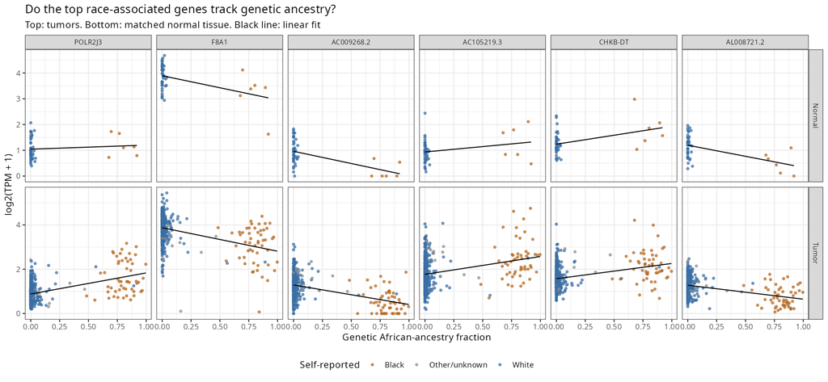

8 gene(s) meet the germline criteria: CHKB-DT, RAMACL, AL008721.2, AC009268.2, IZUMO1, TUBB8, FP565260.1, F8A1. These are better explained by common inherited variants whose frequency differs between African and European populations (for example expression QTLs or copy-number polymorphisms) than by tumor biology, and should not be read as tumor biomarkers of race. Confirming a specific variant would need the germline genotypes, which are controlled-access.

# 8 Molecular subtypes

TCGA’s 2015 analysis grouped primary prostate cancers by mutually exclusive driver events: fusions of **ERG** or other ETS genes (ETV1, ETV4, FLI1), and mutations in **SPOP** or **FOXA1** (Cancer Genome Atlas Research Network 2015). Those labels cover 333 of 497 tumors here. ERG-fusion tumors switch ERG on strongly, so ERG status was also called from ERG expression for every tumor (threshold log<sub>2</sub>(TPM+1) = 4.77). That call agrees with the published label in 98.2% of labelled tumors.

TCGA 2015 molecular subtype groups

| Subtype | N | % |
| --- | --- | --- |
|  | 164 | 33.0 |
| ERG | 152 | 30.6 |
| Other | 89 | 17.9 |
| ETS_other | 46 | 9.3 |
| SPOP | 37 | 7.4 |
| FOXA1 | 9 | 1.8 |

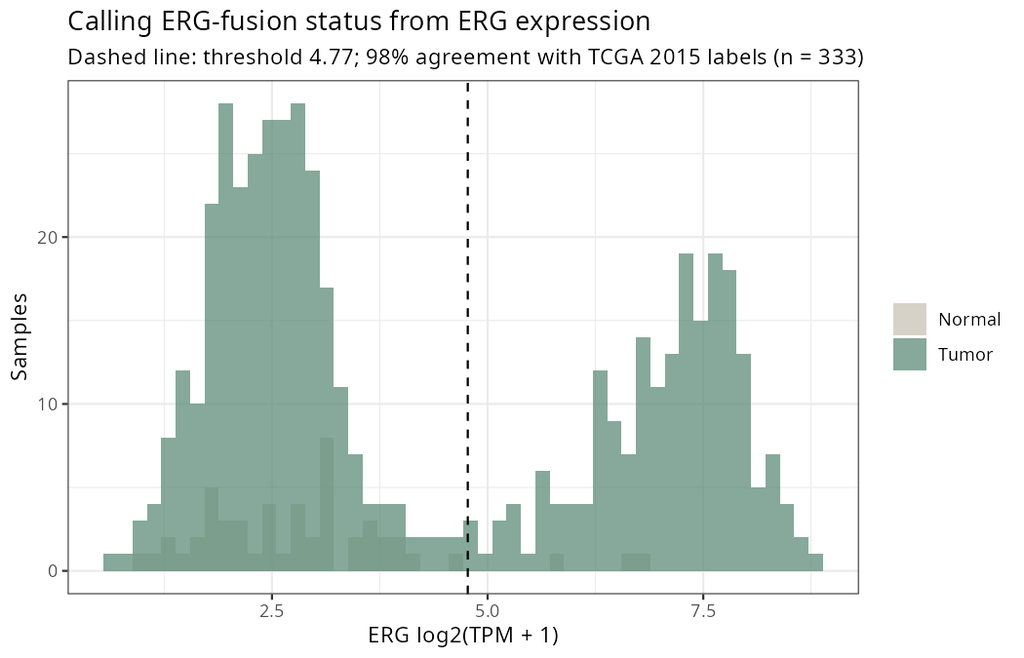

Figure 17: ERG expression in tumors and normals; dashed line is the ERG-positive threshold.

## 8.1 ERG fusion and African ancestry

ERG fusions are reported to be less common in men of African ancestry; a meta-analysis put prevalence at about 49% in men of European descent and 25% in men of African descent, and a South African study found 13% (Blackburn et al. 2019). Here, 28.3% of tumors from patients with AFR ≥ 0.5 (n = 53) are ERG-positive by expression, against 42.2% of the rest. Adjusted for Gleason group and age, the odds of an ERG-positive tumor change by a factor of 0.367 from AFR 0 to 1 (p = 0.0169).

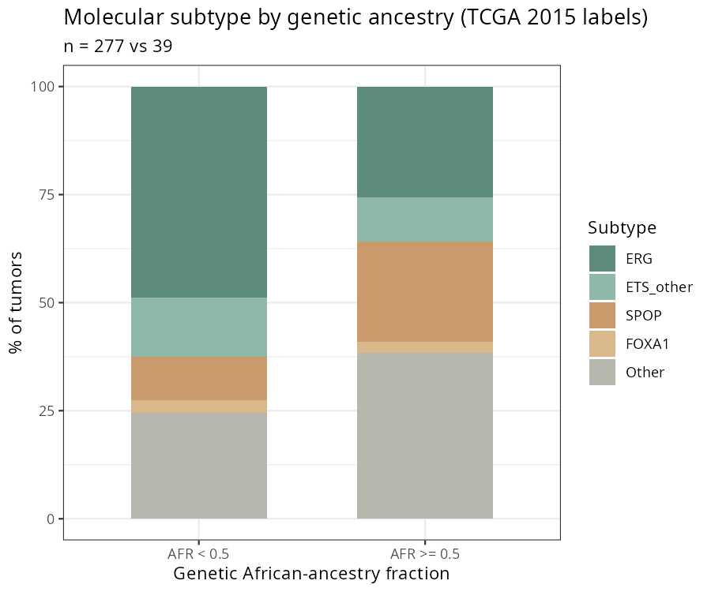

Figure 18: Subtype composition by genetic ancestry.

## 8.2 Does the tumor-vs-normal picture differ by ERG status?

Among the 52 patient pairs, 26 tumors are ERG-positive and 26 ERG-negative. A nested model estimated the tumor-vs-normal change separately in each group. 2008 genes have a tumor effect that differs by ERG status (FDR < 0.05). At pathway level, with each patient counted once, 4 Hallmark sets differ (FDR < 0.05).

Hallmark sets with the largest ERG+ vs ERG− difference in tumor effect

| Pathway | NES ERG+ | NES ERG− | Patient-level p | FDR |
| --- | --- | --- | --- | --- |
| PANCREAS BETA CELLS | -1.02 | -1.47 | 1.6e-05 | 0.0008 |
| CHOLESTEROL HOMEOSTASIS | -1.17 | 1.21 | 5.5e-05 | 0.0014 |
| ANDROGEN RESPONSE | 1.52 | 2.51 | 1.9e-03 | 0.0310 |
| MTORC1 SIGNALING | 1.25 | 1.84 | 3.2e-03 | 0.0400 |
| HEME METABOLISM | -1.30 | 0.90 | 6.6e-03 | 0.0660 |
| UNFOLDED PROTEIN RESPONSE | 1.76 | 2.13 | 1.7e-02 | 0.1400 |
| GLYCOLYSIS | 1.09 | 1.46 | 2.2e-02 | 0.1600 |
| PEROXISOME | 0.87 | 1.20 | 3.9e-02 | 0.2400 |

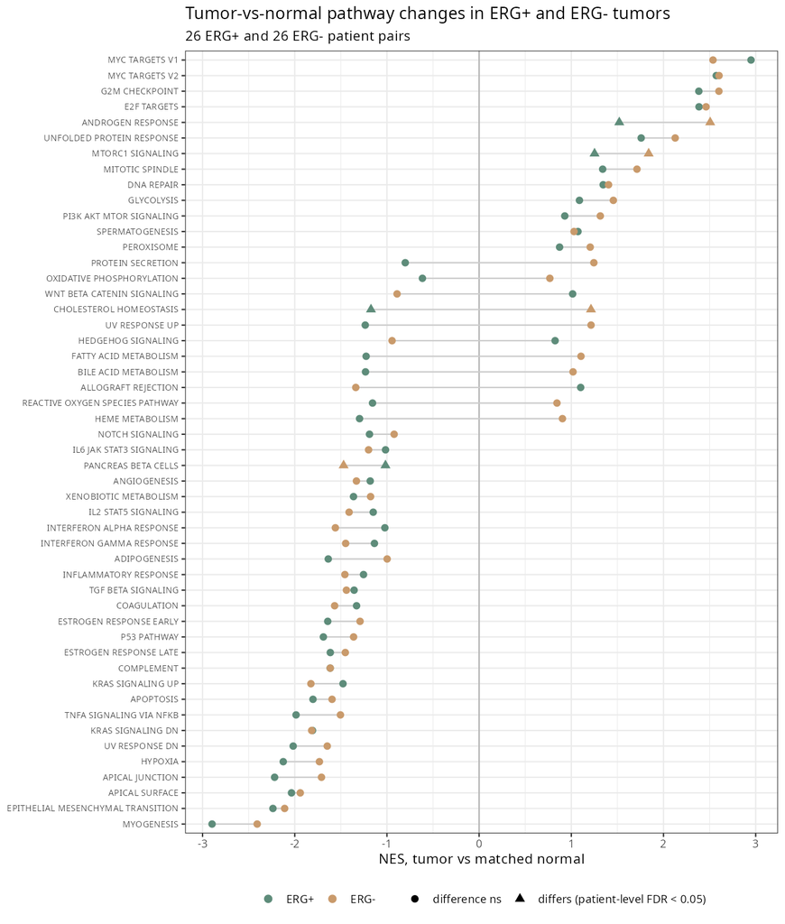

Figure 19: Tumor-vs-normal Hallmark changes in ERG-positive and ERG-negative pairs.

## 8.3 Subtype-specific programmes and progression

Among labelled tumors, each subtype was compared with the “Other” group, adjusting for Gleason group and age (dots in the heatmap mark FDR < 0.05).

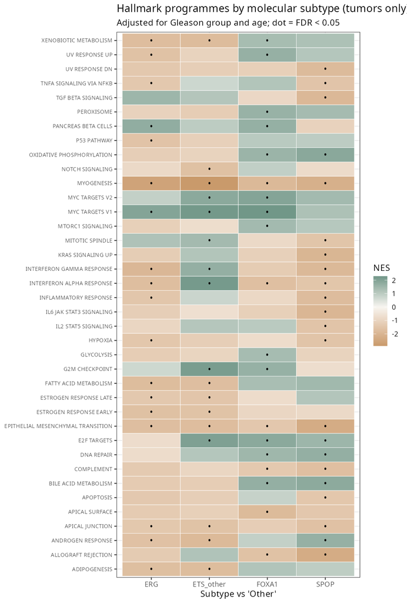

Figure 20: Hallmark NES by molecular subtype, relative to ‘Other’.

Progression-free interval by ERG status and subtype group (Cox models)

| Model | Term | HR | 95% CI | p | n | Events |
| --- | --- | --- | --- | --- | --- | --- |
| ERG (expression) unadjusted | erg_expr_positiveTRUE | 0.84 | 0.53–1.33 | 0.45 | 468 | 77 |
| ERG (expression) + T + age, stratified by Gleason | erg_expr_positiveTRUE | 0.76 | 0.47–1.21 | 0.24 | 468 | 77 |
| Subtype group (paper) + T + age, stratified by Gleason | subtype:ERG | 1.04 | 0.43–2.55 | 0.93 | 311 | 43 |
| Subtype group (paper) + T + age, stratified by Gleason | subtype:ETS_other | 2.17 | 0.75–6.32 | 0.15 | 311 | 43 |
| Subtype group (paper) + T + age, stratified by Gleason | subtype:SPOP | 2.02 | 0.76–5.34 | 0.16 | 311 | 43 |

Subtype groups with fewer than three progression events (FOXA1) were merged into ‘Other’ for the Cox model, because a group with no events has no estimable hazard ratio. Subtype analyses are limited by group sizes: SPOP and FOXA1 tumors are a small minority, and only 53 tumors come from patients with majority African ancestry.

# 9 Tissue composition

Bulk RNA-seq measures a mixture of tumor cells, stroma and immune cells. Composition was estimated for every sample with three signature-based methods: **ESTIMATE** stromal and immune scores (Yoshihara et al. 2013), **MCP-counter** abundance scores for eight immune and two stromal populations (Becht et al. 2016), and marker scores for smooth muscle (ACTG2, DES, CNN1, MYH11, ACTA2, TAGLN) and basal epithelium (KRT5, KRT15, TP63). These are relative scores, not absolute cell fractions.

## 9.1 Tumor vs matched normal

Composition in paired samples (Wilcoxon signed-rank, BH-adjusted)

| Score | Median normal | Median tumor | Tumor higher (pairs) | Adjusted p |
| --- | --- | --- | --- | --- |
| smooth_muscle | 1.06 | 0.29 | 5 / 52 | 5.0e-07 |
| basal_epithelium | 1.16 | 0.31 | 7 / 52 | 2.2e-05 |
| mcp_Fibroblasts | 6.49 | 6.11 | 15 / 52 | 8.2e-03 |
| estimate_stromal | -269.55 | -435.37 | 18 / 52 | 1.8e-02 |
| mcp_T_cells | 1.24 | 1.23 | 20 / 52 | 6.8e-02 |
| estimate_immune | -208.84 | -281.62 | 22 / 52 | 8.1e-02 |
| mcp_Endothelial_cells | 2.91 | 2.86 | 23 / 52 | 1.3e-01 |

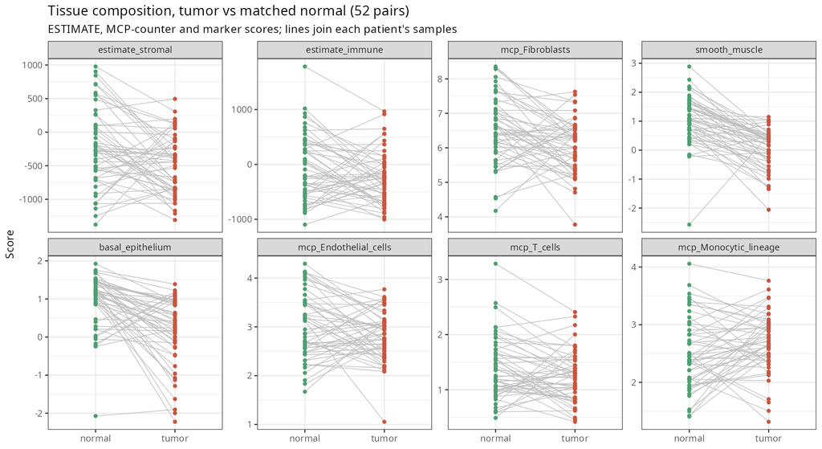

Figure 21: Composition scores in each patient’s tumor and normal sample.

## 9.2 Which pathway changes reflect composition?

The paired model was refitted twice:

1. `~ patient + stromal + immune + condition`, using ESTIMATE scores.
2. The same, plus the smooth-muscle and basal-epithelium scores.

The second model is needed because ESTIMATE’s stromal signature is built from fibroblast and extracellular-matrix genes, while prostate stroma is mostly smooth muscle. Tumor status correlates with the ESTIMATE stromal score at only r = -0.233, but with the smooth-muscle score at r = -0.553 and the basal score at r = -0.455. Each adjustment removes the part of a change explained by differing composition between a patient’s two samples.

- **Robust under both adjustments (16):** MYC TARGETS V1, MYC TARGETS V2, G2M CHECKPOINT, E2F TARGETS, ANDROGEN RESPONSE, MITOTIC SPINDLE, ADIPOGENESIS, ESTROGEN RESPONSE LATE, P53 PATHWAY, APOPTOSIS, UV RESPONSE DN, HYPOXIA, APICAL JUNCTION, APICAL SURFACE, EPITHELIAL MESENCHYMAL TRANSITION, MYOGENESIS.
- **Lost after ESTIMATE adjustment (7):** DNA REPAIR, TGF BETA SIGNALING, COAGULATION, PANCREAS BETA CELLS, COMPLEMENT, KRAS SIGNALING UP, TNFA SIGNALING VIA NFKB. These mostly reflect immune and fibroblast content.
- **Lost only after adding smooth muscle and basal scores (4):** UNFOLDED PROTEIN RESPONSE, MTORC1 SIGNALING, ESTROGEN RESPONSE EARLY, KRAS SIGNALING DN. These mostly reflect loss of fibromuscular stroma and basal cells.
- **Significant only after adjustment (3):** OXIDATIVE PHOSPHORYLATION, ALLOGRAFT REJECTION, IL6 JAK STAT3 SIGNALING.

The robust sets are the strongest candidates for changes within tumor cells. The smooth-muscle score shares genes with the Hallmark myogenesis set, so myogenesis weakening under the second model is partly circular rather than evidence by itself.

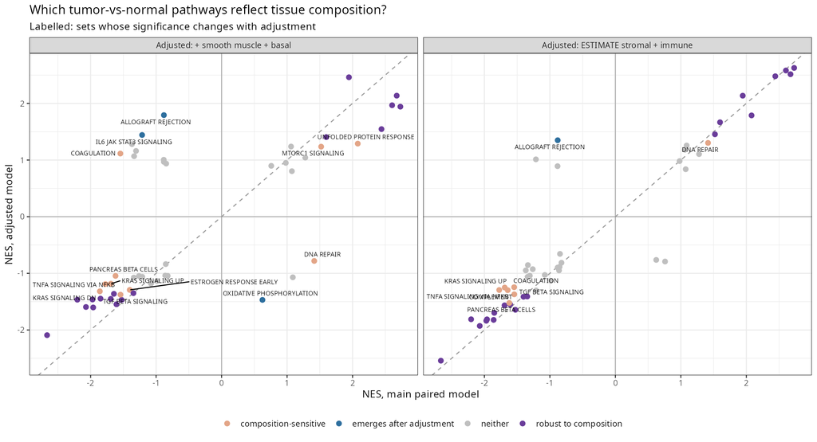

Figure 22: Hallmark NES before and after composition adjustment, for both adjusted models.

## 9.3 Composition and the race comparison

Composition of Black vs White patients’ tumors (linear model with Gleason group and age)

| Score | Difference (SD, Black − White) | Adjusted p |
| --- | --- | --- |
| mcp_B_lineage | 0.37 | 0.17 |
| mcp_T_cells | 0.32 | 0.18 |
| smooth_muscle | -0.30 | 0.18 |
| mcp_Cytotoxic_lymphocytes | 0.27 | 0.24 |
| mcp_Neutrophils | -0.25 | 0.24 |
| estimate_immune | 0.24 | 0.25 |
| basal_epithelium | -0.17 | 0.51 |
| mcp_Myeloid_dendritic_cells | 0.13 | 0.53 |

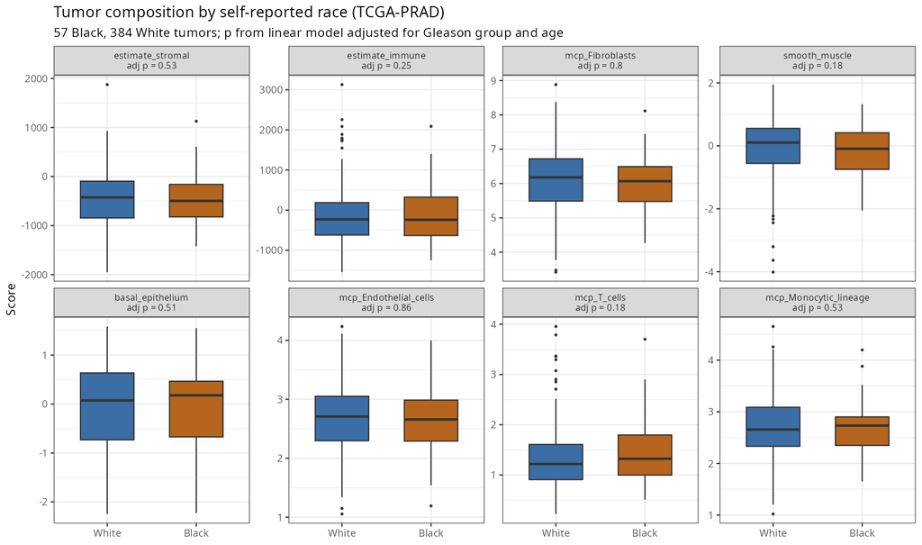

Figure 23: Tumor composition by self-reported race.

Immune content is modestly higher in Black patients’ tumors (ESTIMATE immune score +0.24 SD, adjusted p = 0.248). To ask whether this explains the interferon difference, the race model was adjusted in two ways:

- **ESTIMATE stromal and immune scores.** 22 genes of the ESTIMATE immune signature are also in the Hallmark interferon sets, so this adjustment can remove interferon signal itself.
- **MCP-counter T-cell, B-lineage and fibroblast scores**, which are built from lineage marker genes.

Interferon and allograft-rejection sets, Black vs White tumors, under each adjustment

| Pathway | NES main | padj main | NES ESTIMATE-adj | padj ESTIMATE | NES MCP-adj | padj MCP |
| --- | --- | --- | --- | --- | --- | --- |
| INTERFERON GAMMA RESPONSE | 1.84 | 2.2e-05 | -0.84 | 1.000 | -0.99 | 0.560 |
| INTERFERON ALPHA RESPONSE | 1.96 | 1.3e-04 | -0.70 | 1.000 | -0.71 | 1.000 |
| ALLOGRAFT REJECTION | 1.61 | 1.7e-03 | -1.34 | 0.036 | -1.43 | 0.011 |

# 10 Association with progression

**Outcome.** Progression-free interval (PFI) from the TCGA Pan-Cancer Clinical Data Resource (Liu et al. 2018), the endpoint recommended for TCGA-PRAD because deaths are few. **Samples.** One primary tumor per patient: 497 tumors with 93 progression events and median follow-up 25.9 months. **Models.** Cox proportional hazards per standard deviation of each score, univariable and adjusted for Gleason group, pathological T stage and age (461 complete cases, 76 events). The clinical-only model has C-index 0.719.

Cox models adjusted for Gleason group, T stage and age (BH across scores)

| Score | HR per SD | 95% CI | Adjusted p | C-index | Gain vs clinical | PH test p |
| --- | --- | --- | --- | --- | --- | --- |
| hm_ANDROGEN_RESPONSE | 0.85 | 0.68–1.06 | 0.98 | 0.726 | +0.007 | 0.79 |
| hm_MYOGENESIS | 0.88 | 0.70–1.10 | 0.98 | 0.736 | +0.017 | 0.81 |
| smooth_muscle | 0.89 | 0.72–1.10 | 0.98 | 0.737 | +0.018 | 0.80 |
| hm_EPITHELIAL_MESENCHYMAL_TRANSITION | 0.89 | 0.71–1.11 | 0.98 | 0.729 | +0.010 | 0.82 |
| mcp_Fibroblasts | 0.90 | 0.73–1.13 | 0.98 | 0.728 | +0.009 | 0.83 |
| tcga_tumor_signature | 1.07 | 0.85–1.35 | 0.98 | 0.731 | +0.012 | 0.83 |
| hm_INTERFERON_GAMMA_RESPONSE | 0.95 | 0.76–1.19 | 0.98 | 0.714 | -0.005 | 0.29 |
| mcp_CD8_T_cells | 1.04 | 0.85–1.27 | 0.98 | 0.726 | +0.007 | 0.41 |
| mcp_Cytotoxic_lymphocytes | 0.96 | 0.78–1.18 | 0.98 | 0.718 | -0.001 | 0.75 |
| estimate_stromal | 0.96 | 0.77–1.21 | 0.98 | 0.723 | +0.004 | 0.83 |
| hm_E2F_TARGETS | 1.04 | 0.81–1.32 | 0.98 | 0.731 | +0.013 | 0.55 |
| estimate_immune | 1.03 | 0.83–1.26 | 0.98 | 0.721 | +0.002 | 0.40 |
| hm_INTERFERON_ALPHA_RESPONSE | 0.99 | 0.79–1.24 | 0.98 | 0.712 | -0.007 | 0.15 |
| hm_MYC_TARGETS_V1 | 1.01 | 0.80–1.27 | 0.98 | 0.720 | +0.002 | 0.82 |
| hm_G2M_CHECKPOINT | 1.00 | 0.78–1.28 | 0.98 | 0.717 | -0.002 | 0.57 |

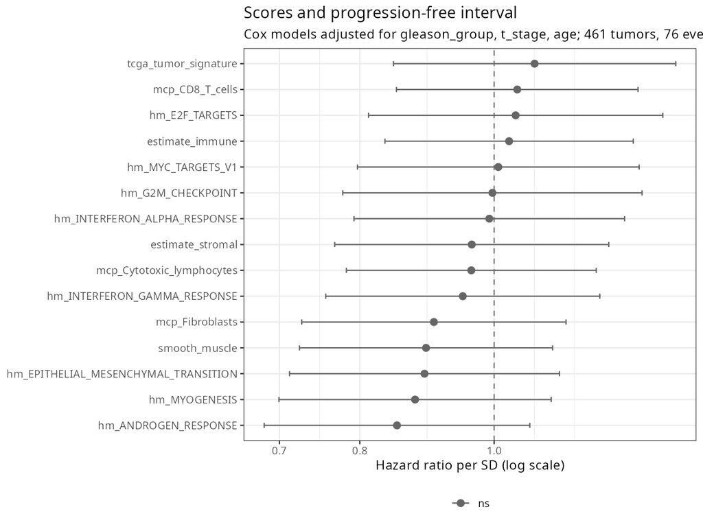

Figure 24: Adjusted hazard ratios per SD with 95% confidence intervals.

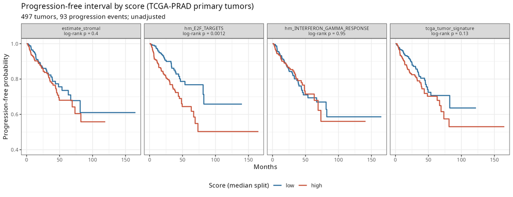

Figure 25: Kaplan–Meier curves, median split (unadjusted).

**No score was independently associated with progression.** After adjusting for Gleason group, T stage and age, hazard ratios ranged from 0.85 to 1.07 per SD, and the largest C-index gain over the clinical model was +0.018 (smooth_muscle). Before adjustment, hm_E2F_TARGETS (HR 1.43, adjusted p = 0.039) predicted faster progression. High-grade tumors proliferate more, so this prognostic signal is largely carried by Gleason grade. Median-split curves are shown for illustration only; the Cox models are the formal test. Only 9 of 57 Black patients had a progression event, too few to test whether any association differs by race.

# 11 Limitations

- **Bulk tissue.** Tumor-vs-normal differences mix changes in cell state with changes in cell-type composition, especially stromal loss. ESTIMATE and MCP-counter give relative signature scores, not true cell fractions, and adjusting for them can also remove real biology when composition and condition are intertwined.
- **Progression.** PFI in prostate cancer mostly reflects new tumor events after surgery, follow-up is short, and the scores were not tested in an independent outcome cohort.
- **Purity.** Published purity estimates exist for only some samples. All pairs were kept, and results were robust to excluding the borderline ones.
- **Validation cohort.** GSE104131 is small (13 pairs) and high-grade only, with counts from a different pipeline and annotation (Entrez IDs mapped to symbols).
- **Ancestry.** Self-reported race is not genetic ancestry; genetic ancestry proportions were used as a check (Section on genetic ancestry), but African-ancestry samples remain few. Race and ancestry are confounded with collection site and grade in TCGA. Tumor-only comparisons cannot show tumor-vs-normal differences. All ancestry results are exploratory.
- **Multiple testing.** FDR is controlled within each analysis, not across the whole project.

# 12 Reproducibility

```bash
micromamba create -n prad-dge -f workflow/envs/r-bioc.yaml
micromamba activate prad-dge
snakemake --cores 4
```

- GDC data release: Data Release 46.0 - August 10, 2026, downloaded 2026-11-02 with TCGAbiolinks 2.38.0.
- GSE104131 counts and series matrix were downloaded manually from GEO into `data/raw/geo/`; see the README.
- Every number in this report is read from pipeline outputs at render time.

# References

1. Cancer Genome Atlas Research Network. The molecular taxonomy of primary prostate cancer. *Cell* 2015;163:1011–1025.
2. Colaprico A, et al. TCGAbiolinks: an R/Bioconductor package for integrative analysis of TCGA data. *Nucleic Acids Res* 2016;44:e71.
3. Love MI, Huber W, Anders S. Moderated estimation of fold change and dispersion for RNA-seq data with DESeq2. *Genome Biol* 2014;15:550.
4. Zhu A, Ibrahim JG, Love MI. Heavy-tailed prior distributions for sequence count data: removing the noise and preserving large differences. *Bioinformatics* 2019;35:2084–2092.
5. Korotkevich G, et al. Fast gene set enrichment analysis. *bioRxiv* 2021. doi:10.1101/060012.
6. Liberzon A, et al. The Molecular Signatures Database Hallmark gene set collection. *Cell Syst* 2015;1:417–425.
7. Wallace TA, et al. Tumor immunobiological differences in prostate cancer between African-American and European-American men. *Cancer Res* 2008;68:927–936.
8. Awasthi S, et al. Comparative genomics reveals distinct immune-oncologic pathways in African American men with prostate cancer. *Clin Cancer Res* 2021;27:320–329.
9. Cohen T, et al. Ancient out-of-Africa mitochondrial DNA variants associate with distinct mitochondrial gene expression patterns. *PLoS Genet* 2016;12:e1006407.
10. GEO accession GSE104131: RNA sequencing of prostate cancer and normal tissue from African Americans and European Americans.
11. Yoshihara K, et al. Inferring tumour purity and stromal and immune cell admixture from expression data. *Nat Commun* 2013;4:2612.
12. Becht E, et al. Estimating the population abundance of tissue-infiltrating immune and stromal cell populations using gene expression. *Genome Biol* 2016;17:218.
13. Liu J, et al. An integrated TCGA pan-cancer clinical data resource to drive high-quality survival outcome analytics. *Cell* 2018;173:400–416.
14. Carrot-Zhang J, et al. Comprehensive analysis of genetic ancestry and its molecular correlates in cancer. *Cancer Cell* 2020;37:639–654.
15. Blackburn J, et al. TMPRSS2-ERG fusions linked to prostate cancer racial health disparities: a focus on Africa. *Prostate* 2019;79:1191–1196.
16. Ghana Prostate Study: TMPRSS2:ERG in West African men and a meta-analysis of racial differences (PMC5860576).